# Part I — Exploratory Data Analysis

### Prosper Loan Dataset

**By: Reema Kusa**

This notebook explores the Prosper Loan Dataset through systematic exploratory data visualization.

## Overall Exploration Questions

**What is the structure of your dataset?**  
Answer:  
The Prosper dataset contains individual loan records. Each row represents one loan, and there are many columns describing borrower characteristics (income range, credit score, occupation), loan terms (amount, term, interest rate), and performance (loan status, Prosper rating). The dataset has a large number of observations and many features.

**What are the main feature(s) of interest in your dataset?**  
Answer:  
The main features of interest in this investigation are:

- `BorrowerRate` (interest rate)
- `LoanOriginalAmount` (original loan amount)
- `ProsperRating (Alpha)` (risk rating)
- `IncomeRange`
- `LoanStatus`
- `CreditScoreRangeUpper`

**What features in the dataset do you think will help support your investigation into your feature(s) of interest?**  
Answer:  
I expect borrower credit score, Prosper rating, and income range to be most useful in explaining differences in interest rates, loan amounts, and loan performance. Loan term and listing category may also provide additional context.

### Univariate Exploration

**Question:**  
What do the distributions of the main numeric and categorical variables look like? Are there any unusual patterns, skewness, or outliers?

### Bivariate Exploration

**Question:**  
What relationships exist between loan amount, interest rate, and key categorical variables such as `ProsperRating (Alpha)` and `IncomeRange`?

### Multivariate Exploration

**Question:**  
Are there any interesting or surprising interactions between borrower risk, credit score, income, and loan performance?

```python
import pandas as pd
import numpy as np
import matplotlib.pyplot as plt
import seaborn as sns
from pathlib import Path

sns.set_style('whitegrid')
plt.rcParams['figure.figsize'] = (10,6)

LoanStatus_order = ['Current','Completed','Chargedoff','Defaulted','Past Due (1-15 days)','Past Due (16-30 days)','Past Due (31-60 days)','Past Due (61-90 days)','Past Due (91-120 days)','Past Due (>120 days)','FinalPaymentInProgress','Cancelled']
print('Libraries loaded.')
```

```
Libraries loaded.
```

```python
from pathlib import Path


# Search recursively for the file
files = list(Path('.').rglob('prosperLoanData.csv'))
if not files:
    raise FileNotFoundError("prosperLoanData.csv not found anywhere in the project.")

df = pd.read_csv(files[0])
df.head()
```

|  | ListingKey | ListingNumber | ListingCreationDate | CreditGrade | Term | LoanStatus | ClosedDate | BorrowerAPR | BorrowerRate | LenderYield | ... | LP_ServiceFees | LP_CollectionFees | LP_GrossPrincipalLoss | LP_NetPrincipalLoss | LP_NonPrincipalRecoverypayments | PercentFunded | Recommendations | InvestmentFromFriendsCount | InvestmentFromFriendsAmount | Investors |
| --- | --- | --- | --- | --- | --- | --- | --- | --- | --- | --- | --- | --- | --- | --- | --- | --- | --- | --- | --- | --- | --- |
| 0 | 1021339766868145413AB3B | 193129 | 2007-08-26 19:09:29.263000000 | C | 36 | Completed | 2009-08-14 00:00:00 | 0.16516 | 0.1580 | 0.1380 | ... | -133.18 | 0.0 | 0.0 | 0.0 | 0.0 | 1.0 | 0 | 0 | 0.0 | 258 |
| 1 | 10273602499503308B223C1 | 1209647 | 2014-02-27 08:28:07.900000000 | NaN | 36 | Current | NaN | 0.12016 | 0.0920 | 0.0820 | ... | 0.00 | 0.0 | 0.0 | 0.0 | 0.0 | 1.0 | 0 | 0 | 0.0 | 1 |
| 2 | 0EE9337825851032864889A | 81716 | 2007-01-05 15:00:47.090000000 | HR | 36 | Completed | 2009-12-17 00:00:00 | 0.28269 | 0.2750 | 0.2400 | ... | -24.20 | 0.0 | 0.0 | 0.0 | 0.0 | 1.0 | 0 | 0 | 0.0 | 41 |
| 3 | 0EF5356002482715299901A | 658116 | 2012-10-22 11:02:35.010000000 | NaN | 36 | Current | NaN | 0.12528 | 0.0974 | 0.0874 | ... | -108.01 | 0.0 | 0.0 | 0.0 | 0.0 | 1.0 | 0 | 0 | 0.0 | 158 |
| 4 | 0F023589499656230C5E3E2 | 909464 | 2013-09-14 18:38:39.097000000 | NaN | 36 | Current | NaN | 0.24614 | 0.2085 | 0.1985 | ... | -60.27 | 0.0 | 0.0 | 0.0 | 0.0 | 1.0 | 0 | 0 | 0.0 | 20 |

5 rows × 81 columns

```python
print(df.shape)
df.info()
```

```
(113937, 81)
<class 'pandas.core.frame.DataFrame'>
RangeIndex: 113937 entries, 0 to 113936
Data columns (total 81 columns):
 #   Column                               Non-Null Count   Dtype
---  ------                               --------------   -----
 0   ListingKey                           113937 non-null  object
 1   ListingNumber                        113937 non-null  int64
 2   ListingCreationDate                  113937 non-null  object
 3   CreditGrade                          28953 non-null   object
 4   Term                                 113937 non-null  int64
 5   LoanStatus                           113937 non-null  object
 6   ClosedDate                           55089 non-null   object
 7   BorrowerAPR                          113912 non-null  float64
 8   BorrowerRate                         113937 non-null  float64
```

[output cut: 74 more lines]

```python
cols_needed=['LoanStatus','LoanOriginalAmount','BorrowerRate','IncomeRange','Term','Occupation','ProsperRating (Alpha)','CreditScoreRangeUpper','ListingCategory (numeric)']
df_small=df[cols_needed].copy()
df_small.head()
```

|  | LoanStatus | LoanOriginalAmount | BorrowerRate | IncomeRange | Term | Occupation | ProsperRating (Alpha) | CreditScoreRangeUpper | ListingCategory (numeric) |
| --- | --- | --- | --- | --- | --- | --- | --- | --- | --- |
| 0 | Completed | 9425 | 0.1580 | $25,000-49,999 | 36 | Other | NaN | 659.0 | 0 |
| 1 | Current | 10000 | 0.0920 | $50,000-74,999 | 36 | Professional | A | 699.0 | 2 |
| 2 | Completed | 3001 | 0.2750 | Not displayed | 36 | Other | NaN | 499.0 | 0 |
| 3 | Current | 10000 | 0.0974 | $25,000-49,999 | 36 | Skilled Labor | A | 819.0 | 16 |
| 4 | Current | 15000 | 0.2085 | $100,000+ | 36 | Executive | D | 699.0 | 2 |

```python
df_small['LoanStatus'] = pd.Categorical(
    df_small['LoanStatus'],
    categories=LoanStatus_order,
    ordered=True
)

df_small['ProsperRating (Alpha)'] = pd.Categorical(
    df_small['ProsperRating (Alpha)'],
    categories=['HR','E','D','C','B','A','AA'],
    ordered=True
)

IncomeRange_order = ["$0", "$1-24,999", "$25,000-49,999", "$50,000-74,999", "$75,000-99,999", "$100,000+"]

df_small['IncomeRange'] = df_small['IncomeRange'].replace(
    ['Not employed','Not displayed'],
    np.nan
)

df_small['IncomeRange'] = pd.Categorical(
    df_small['IncomeRange'],
    categories=IncomeRange_order,
    ordered=True
)

df_small.head()
```

|  | LoanStatus | LoanOriginalAmount | BorrowerRate | IncomeRange | Term | Occupation | ProsperRating (Alpha) | CreditScoreRangeUpper | ListingCategory (numeric) |
| --- | --- | --- | --- | --- | --- | --- | --- | --- | --- |
| 0 | Completed | 9425 | 0.1580 | $25,000-49,999 | 36 | Other | NaN | 659.0 | 0 |
| 1 | Current | 10000 | 0.0920 | $50,000-74,999 | 36 | Professional | A | 699.0 | 2 |
| 2 | Completed | 3001 | 0.2750 | NaN | 36 | Other | NaN | 499.0 | 0 |
| 3 | Current | 10000 | 0.0974 | $25,000-49,999 | 36 | Skilled Labor | A | 819.0 | 16 |
| 4 | Current | 15000 | 0.2085 | $100,000+ | 36 | Executive | D | 699.0 | 2 |

```python
def plot_hist_with_mean(data,column,bins=40,title=None):
    plt.figure(figsize=(10,6))
    sns.histplot(data[column].dropna(), bins=bins, kde=False)
    mean_val=data[column].mean()
    plt.axvline(mean_val,color='red',linestyle='--',label=f"Mean: {mean_val:.2f}")
    plt.title(title)
    plt.xlabel(column)
    plt.ylabel('Count')
    plt.legend()
    plt.show()
```

### Distribution of Borrower Interest Rates

**Question:**  
What is the distribution of borrower interest rates (`BorrowerRate`)? Are there many very high-rate loans?

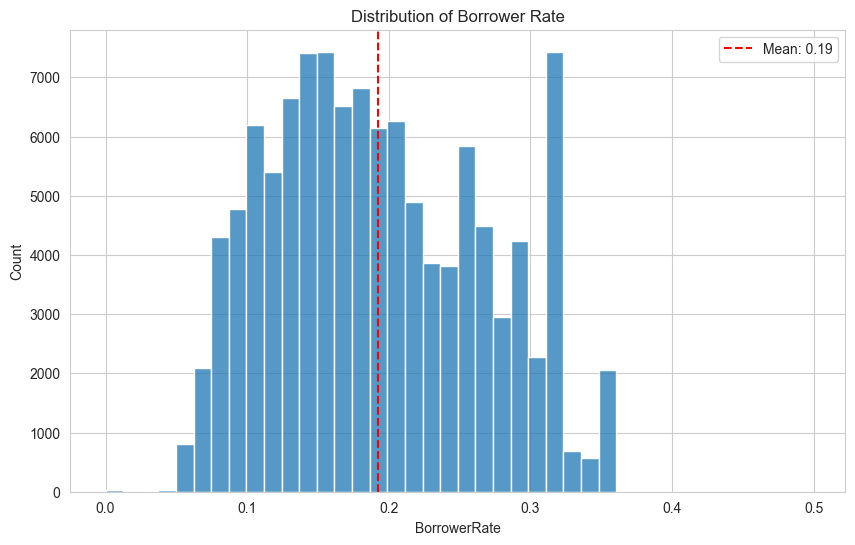

```python
plot_hist_with_mean(df_small, 'BorrowerRate', title='Distribution of Borrower Rate')
```

### Distribution of Original Loan Amounts

**Question:**  
What is the distribution of original loan amounts? Are most loans small, medium, or large?

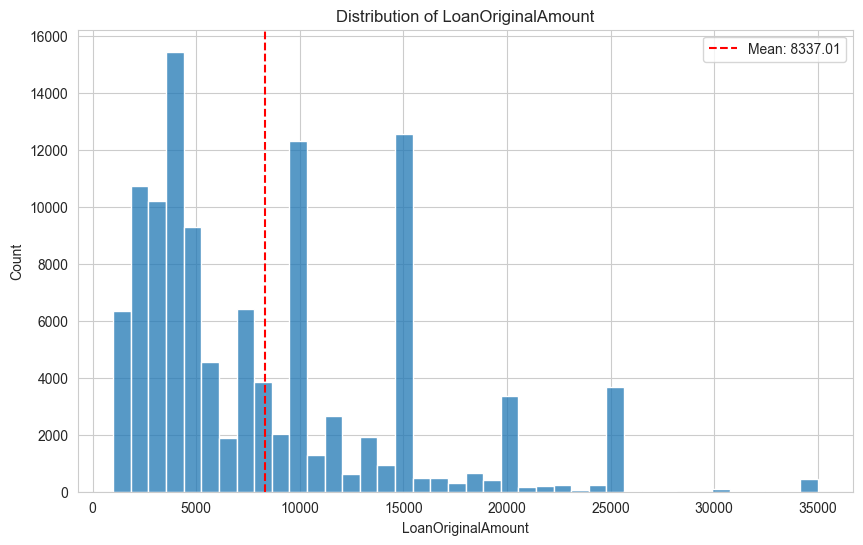

```python
plot_hist_with_mean(df_small, 'LoanOriginalAmount', title='Distribution of LoanOriginalAmount')
```

**Observation:**  
The distribution of `LoanOriginalAmount` is strongly right-skewed. Most loans are for smaller amounts, while a small proportion of loans have very large principal values, which pulls the mean to the right.

### Counts of Loan Statuses

**Question:**  
How are loans distributed across the different `LoanStatus` categories?

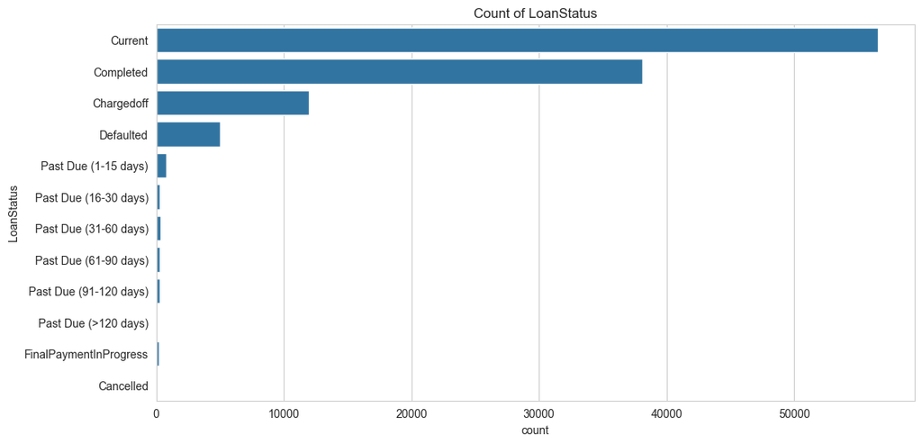

```python
plt.figure(figsize=(12,6))
sns.countplot(data=df_small,y='LoanStatus',order=LoanStatus_order)
plt.title('Count of LoanStatus')
plt.show()
```

**Observation:**  
The majority of loans are either **Current** or **Completed**, indicating that most loans are performing normally or have been fully repaid. Only a minority of loans fall into problematic categories such as **Chargedoff**, **Defaulted**, or the various **Past Due** buckets.

### Loan Amount vs. Borrower Rate

**Question:**  
What is the relationship between the original loan amount and the interest rate charged to the borrower?

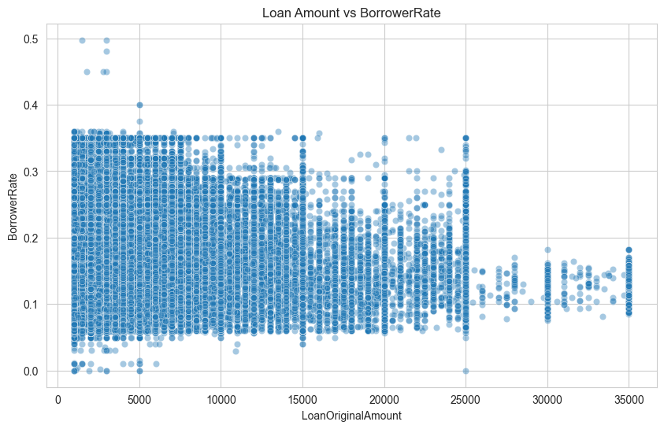

```python
plt.figure(figsize=(10,6))
sns.scatterplot(data=df_small, x='LoanOriginalAmount', y='BorrowerRate', alpha=0.4)
plt.title('Loan Amount vs BorrowerRate')
plt.show()
```

**Observation:**  
The scatter plot shows a wide spread of interest rates for small and medium loan amounts. For very large loans, interest rates tend to be more concentrated and slightly lower on average, suggesting that high-value borrowers may receive somewhat better pricing.

### Borrower Rate by Prosper Rating

**Question:**  
How do interest rates differ across Prosper risk ratings?

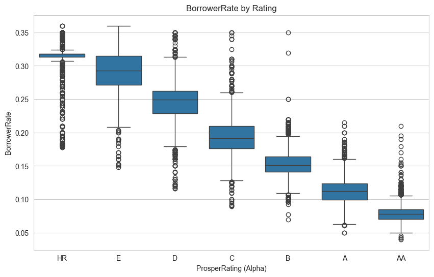

```python
plt.figure(figsize=(10,6))
sns.boxplot(data=df_small, x='ProsperRating (Alpha)', y='BorrowerRate')
plt.title('BorrowerRate by Rating')
plt.show()
```

### Average Loan Amount by Income Range

**Question:**  
Do higher-income borrowers receive larger loans on average?

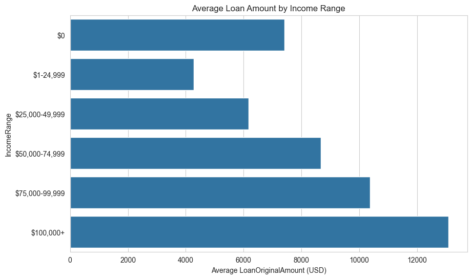

```python
income_summary = df_small.groupby('IncomeRange')['LoanOriginalAmount'].mean().reindex(IncomeRange_order)
plt.figure(figsize=(10,6))
sns.barplot(x=income_summary.values, y=income_summary.index)
plt.title('Average Loan Amount by Income Range')
plt.xlabel('Average LoanOriginalAmount (USD)')
plt.ylabel('IncomeRange')
plt.show()
```

**Observation:**  
Average loan size generally increases with income. Borrowers in the middle and upper income brackets (especially `$75,000-99,999` and `$100,000+`) receive larger loans on average than those in the lowest income groups. This pattern is consistent with the expectation that higher-income borrowers can support larger debts.

### Loan Status by Term Length

**Question:**  
Does loan status vary across different loan terms (e.g., 12, 36, 60 months)?

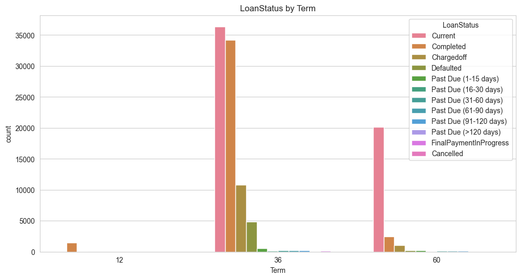

```python
plt.figure(figsize=(12,6))
sns.countplot(data=df_small,x='Term',hue='LoanStatus',hue_order=LoanStatus_order)
plt.title('LoanStatus by Term')
plt.show()
```

### Heatmap of Prosper Rating vs. Loan Status

**Question:**  
Is there a relationship between Prosper risk ratings and final loan status?

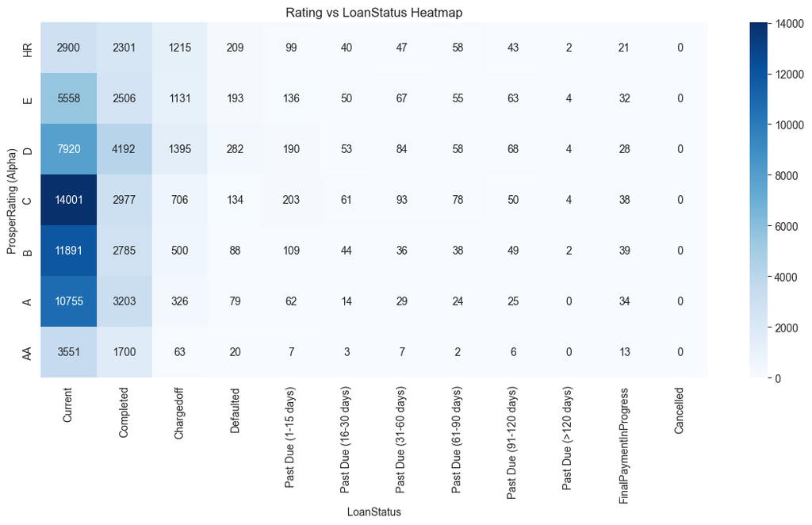

```python
heat = pd.crosstab(
    df_small['ProsperRating (Alpha)'],
    df_small['LoanStatus']
).reindex(columns=LoanStatus_order)

# Fix: convert to int to avoid fmt='d' error
heat = heat.fillna(0).astype(int)

plt.figure(figsize=(14,6))
sns.heatmap(heat, annot=True, fmt='d', cmap='Blues')
plt.title('Rating vs LoanStatus Heatmap')
plt.show()
```

**Observation:**  
The heatmap shows that higher ratings (A, AA) are dominated by **Completed** and **Current** loans, while lower ratings (HR, E, D) have relatively more **Chargedoff**, **Defaulted**, and **Past Due** loans. This confirms that Prosper ratings are predictive of loan performance.

### Loan Amount vs. Borrower Rate Faceted by Rating

**Question:**  
How does the relationship between loan amount and interest rate change across Prosper rating categories?

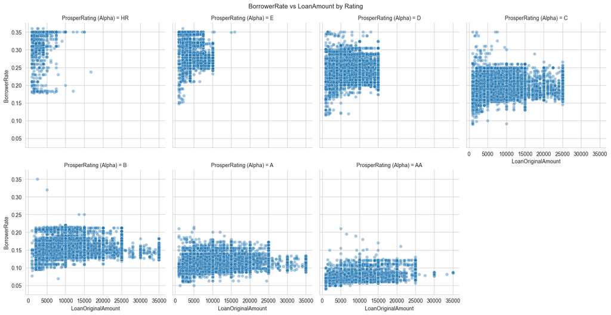

```python
g=sns.FacetGrid(df_small,col='ProsperRating (Alpha)',col_wrap=4,height=4)
g.map_dataframe(sns.scatterplot,x='LoanOriginalAmount',y='BorrowerRate',alpha=0.4)
g.fig.suptitle('BorrowerRate vs LoanAmount by Rating',y=1.02)
plt.show()
```

**Observation:**  
Across facets, higher-rated borrowers (A, AA) cluster at lower interest rates for a given loan amount, while lower-rated borrowers pay higher rates and show more variability. The overall negative relationship between rating and interest rate remains clear even after controlling for loan size.

### Pairwise Relationships Between Key Numeric Features

**Question:**  
What are the pairwise relationships between loan amount, interest rate, and credit score?

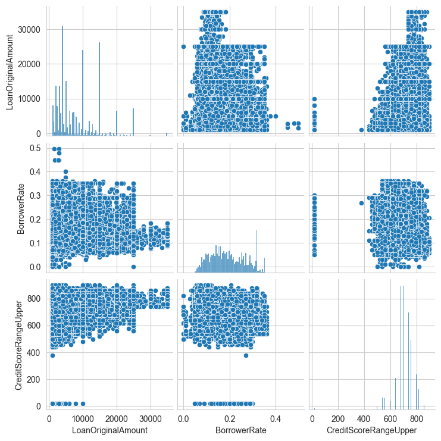

```python
sns.pairplot(df_small[['LoanOriginalAmount','BorrowerRate','CreditScoreRangeUpper']],diag_kind='hist')
plt.show()
```

**Observation:**  
The pair plot indicates a negative relationship between credit score and interest rate, and a positive but noisy relationship between credit score and loan amount. Loan amount and interest rate do not show a simple linear pattern, reflecting the influence of additional underwriting factors.

### Borrower Rate vs. Credit Score

**Question:**  
How does the borrower's credit score relate to the interest rate, and does Prosper rating add additional information?

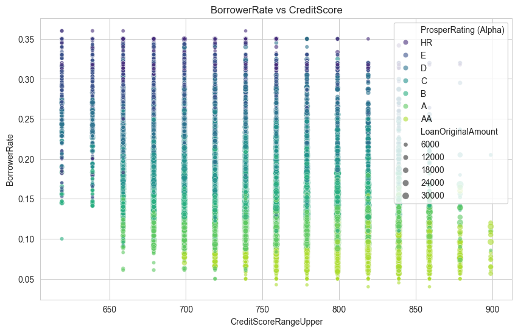

```python
plt.figure(figsize=(10,6))
sns.scatterplot(data=df_small,x='CreditScoreRangeUpper',y='BorrowerRate',size='LoanOriginalAmount',hue='ProsperRating (Alpha)',palette='viridis',alpha=0.6)
plt.title('BorrowerRate vs CreditScore')
plt.show()
```

**Observation:**  
Interest rates generally decrease as `CreditScoreRangeUpper` increases. Within each credit-score level, loans with better Prosper ratings tend to have slightly lower rates, indicating that Prosper ratings complement traditional credit scores in pricing risk.

### Clustered Bar Chart: Average Loan Amount by Rating and Status

**Question:**  
How do average loan amounts vary across combinations of Prosper rating and loan status?

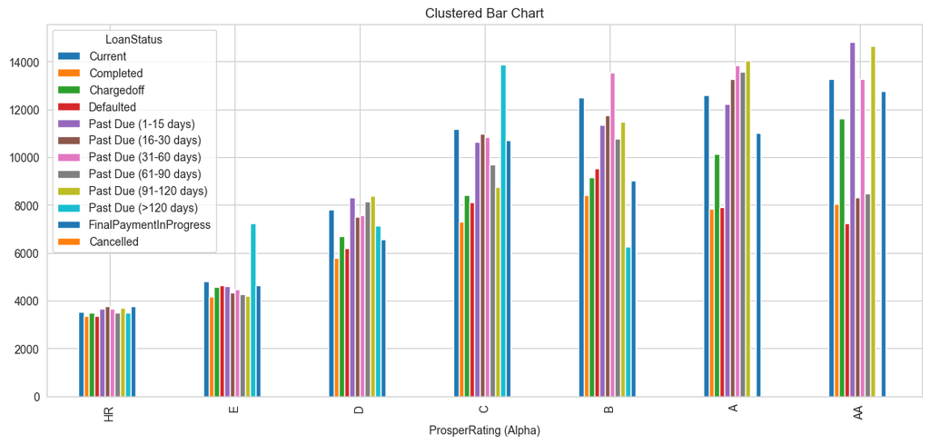

```python
cluster=df_small.pivot_table(values='LoanOriginalAmount',index='ProsperRating (Alpha)',columns='LoanStatus',aggfunc='mean').reindex(columns=LoanStatus_order)
cluster.plot(kind='bar',figsize=(14,6))
plt.title('Clustered Bar Chart')
plt.show()
```

## Summary

Loan amount skewed, borrower rate decreases with rating, income affects loan size, multivariate relations confirm risk factors.